# OLET5602 Project Example

Hani Kim and Taiyun Kim

# Transcription factor target gene prediction through multi-omics datasets

Aim: Prediction is a central application in many real-world data analyses. In this project, we will aim to apply classification techniques for predicting novel transcription factor target genes.

Background: Transcriptional regulation is a vital process in all living organisms. It is orchestrated by transcription factors along with other factors that in concert drive mRNA expression. Distinct transcriptional networks drive development, lineage specification, and cell fate decisions during early embryonic development (Theunissen and Jaenisch, 2017). Recent advances in omics technologies have made it possible to profile genome-wide transcriptional and epigenetic events for investigating transcriptional networks. A key goal is to identify the target genes of transcription factors that drive key transcriptional events over a course of time.

This project template has been developed to help you kick start your project and is by no means an exhaustive template or a definitive guide. Students may present their project in any format that they deem appropriate to fulfil the assessment requirements.

# Load the data and the packages you will use

```r
load("Final_Project_ESC.RData", verbose=T)
```

```
## Loading objects:
##   Transcriptome
##   Proteome
##   H3K4me3
##   H3K27me3
##   PolII
##   H3K4me1
##   H3K27ac
##   H3K9me2
##   cMyc_target_genes
##   cMyc_target_genes_subset
##   OSN_target_genes
##   OSN_target_genes_subset
```

```r
suppressPackageStartupMessages({
    library(e1071)
    library(ggplot2)
    library(ROCR)
    library(dplyr)
    library(tibble)
})
```

# Exploratory analysis of the omics data

Our task is to predict transcription factor target genes from temporally resolved multi-omic datasets that profile embryonic stem cell differentiation. Before embarking on this task, it is important to understand your datasets. A common method to investigate the structure of data is PCA analysis. Let us run PCA analysis on the transcriptome data as an example.

## Transcriptome

Our transcriptome data contains the temporal expression of 19788 genes across 8 timepoints.

```r
head(Transcriptome)
```

```
##                 0hr         1hr          6hr        12hr        24hr
## GNAI3  8.881784e-16  0.29131114  0.618947976  0.48337689  0.71864514
## CDC45  0.000000e+00  0.25062323  0.199000752  0.38800303  0.47163966
## H19    0.000000e+00  0.38475910  0.471216601  0.55341685  1.87279375
## SCML2  8.881784e-16  0.64099671  0.917100751  0.73622935  0.74708761
## NARF  -8.881784e-16 -0.40736349 -1.186942510 -0.69986049 -0.15754727
## CAV2   5.551115e-17  0.01608049  0.002154149  0.07278802  0.06737809
##              36hr        48hr        72hr
## GNAI3  0.90833508  0.63408090  0.81560693
## CDC45  0.20338260 -0.03095025 -0.55159826
## H19    2.77535428  4.17558703  4.34079023
## SCML2  0.71202112 -0.20856228 -1.12588475
## NARF  -0.73012533 -0.11611985 -0.01534405
## CAV2   0.08131677  0.46840687  1.32719756
```

```r
dim(Transcriptome)
```

```
## [1] 19788     8
```

```r
colnames(Transcriptome)
```

```
## [1] "0hr"  "1hr"  "6hr"  "12hr" "24hr" "36hr" "48hr" "72hr"
```

We will use `prcomp` function to plot the PCA. The PCA analysis shows that there is a clear trajectory of the samples from 0h going to 72hr, meaning that the transcriptomes of the cells are dynamically changing across time.

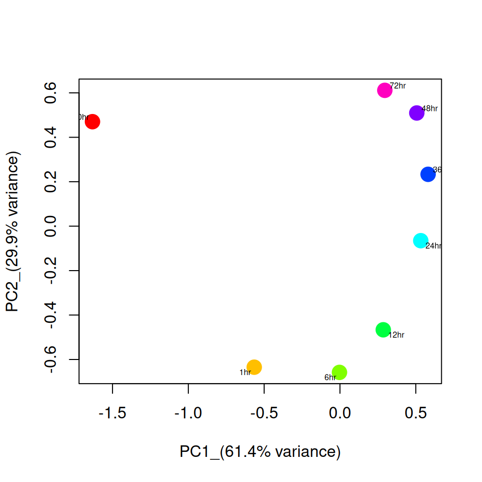

```r
cor.mat <- cor(Transcriptome)
pca.mat <- prcomp(cor.mat)
grp <- rownames(pca.mat$x)
grp.col <- rainbow(nrow(pca.mat$x))
names(grp.col) <- rownames(pca.mat$x)
plot(pca.mat$x[,1], pca.mat$x[,2], col=grp.col[grp], pch=19, cex=2,
     xlab=paste0("PC1_(", round(summary(pca.mat)$importance[2,1]*100,1), "% variance)"),
     ylab=paste0("PC2_(", round(summary(pca.mat)$importance[2,2]*100,1), "% variance)"))
calibrate::textxy(pca.mat$x[,1], pca.mat$x[,2], labs=grp, cex=0.5)
```

Include further any other relevant exploratory analysis your group think is necessary.

## Classification

Here, we will perform a simple demonstration by combining proteomics and transcriptomics dataset to identify Sox2 and Nanog target genes.

```r
# We find the intersecting genes in transcriptome and proteome
genes = intersect(rownames(Transcriptome), rownames(Proteome))
Transcriptome_filter = Transcriptome[which(rownames(Transcriptome) %in% genes),]
Proteome_filter = Proteome[which(rownames(Proteome) %in% genes),]

# We make sure that the genes are in the correct order before we join.
Transcriptome_filter = Transcriptome_filter[order(rownames(Transcriptome_filter)),]
Proteome_filter = Proteome_filter[order(rownames(Proteome_filter)),]
# expect TRUE
identical(rownames(Transcriptome_filter), rownames(Proteome_filter))
```

```
## [1] TRUE
```

```r
# To avoid duplicated names (timepoints) from different omics, we will rename them.
colnames(Transcriptome_filter) = paste("T_", colnames(Transcriptome_filter), sep = "")
colnames(Proteome_filter) = paste("P_", colnames(Proteome_filter), sep = "")

# Combine. Both proteome and transcriptome have already been transformed to comparable scales.
dat = cbind(
  Transcriptome_filter,
  Proteome_filter
)

dim(dat)
```

```
## [1] 8355   15
```

```r
head(dat)
```

```
##                      T_0hr       T_1hr       T_6hr     T_12hr     T_24hr
## 0610009B22RIK 0.000000e+00 -0.04307636  0.42188663  0.4665822  0.6966264
## 0610011F06RIK 0.000000e+00 -0.32955176 -0.60455823 -0.7011195 -0.8381346
## 0610037L13RIK 8.881784e-16  0.05092020  0.09927201  0.1624595  0.1169831
## 1110065P20RIK 0.000000e+00 -0.24404534 -0.17447122 -0.5891415 -0.2154890
## 1600014C10RIK 0.000000e+00 -0.92485355  0.86537686  0.4218354  0.1006763
## 1700007K13RIK 0.000000e+00  0.07680240  0.04442215  0.7240295 -0.1618216
##                    T_36hr     T_48hr     T_72hr        P_1hr       P_6hr
## 0610009B22RIK  0.66533031  0.8411495  0.5037492 -0.371951940 -0.04441325
## 0610011F06RIK -0.89228051 -0.1858615  0.3614008  0.180319011  0.17409955
## 0610037L13RIK  0.09035218  0.1958615  0.1767494 -0.065450165 -0.01574174
## 1110065P20RIK  0.11611208  0.7128412  0.7667672  0.740602273 -0.03864032
## 1600014C10RIK  0.46187455 -1.0221880 -1.3042289 -0.003293602  0.58239756
## 1700007K13RIK -1.18518758 -0.8408930 -1.2759205 -2.444303531 -0.96851257
##                   P_12hr     P_24hr     P_36hr     P_48hr      P_72hr
## 0610009B22RIK -0.6364827 -0.5336049 -1.0929963 -0.5249050 -0.07420068
## 0610011F06RIK -0.0751701 -0.4284919 -0.5676383 -0.8439403 -0.13420502
## 0610037L13RIK -0.1248259 -0.1968088 -0.1827408 -0.1469163 -0.17867815
## 1110065P20RIK -0.3437096 -0.5481601  0.2524110  0.5052008  1.80924607
## 1600014C10RIK  0.4457285  0.3984288  0.7761668  0.6194339 -0.48965028
## 1700007K13RIK  0.9578514  0.4173946 -2.5880652 -2.8753485 -2.45769738
```

```r
# Number of genes which we are given to be targets for Sox2 and Nanog
length(OSN_target_genes_subset)
```

```
## [1] 100
```

```r
# Number of genes in the data that are not identified.
nrow(dat) - length(OSN_target_genes_subset)
```

```
## [1] 8255
```

*Note that the proteome and transcriptome are transformed to be in the comparable scale and thus it is okay to join them. However, the epigenome data provided are in different scale for each histone marks. Thus, they cannot be joined with transcriptome or proteome as shown above, and you will need to work on each of histone marks separately in the epigenome data.*

We have roughly 100 genes known to be targets for Sox2 and Nanog and approximately 8000 genes which are unknown. We will consider all those genes that are not in `OSN_target_genes_subset` as `Other`.

```r
genes = genes[order(genes)]
dat = dat[order(rownames(dat)),]

label = ifelse(genes %in% OSN_target_genes_subset, "OSN", "Other")

table(label)
```

```
## label
##   OSN Other
##    95  8260
```

```r
dat = data.frame(dat)

dat$label = factor(label)
```

This is a huge imabalance and thus we will downsample some of those `Other` classes. In this demonstration, we will perform the most naive approach by subsampling random 100 from the `Other` labels to train the model. Please note that this is not the ideal approach as it will not give the most optimal results. (Hint: One approach is to try to do an ensemble and exploratory analysis to find set of genes that are least likely to be Sox2/Nanog targets through visualisations, clustering, etc.)

```r
# Sampling random 100 Other
set.seed(123)
selection = sample(which(label == "Other"), 100)
selection = c(which(label == "OSN"), selection)
dat_train = dat[selection,]
```